# Supplemental Figures

Yuta Suzuki

4/23/2021

# Article information

Temporal dynamics of auditory bistable perception correlated with a fluctuation of baseline pupil size

Yuta Suzuki, Hsin-I Liao, Shigeto Furukawa

NTT Communication Science Laboratories, NTT Corporation, Atsugi 243-0198, Japan

*Corresponding author: Yuta Suzuki NTT Communication Science Laboratories, NTT Corporation, Atsugi 243-0198, Japan Tel: +81-046-240-3525, E-mail: yuuta.suzuki.fc@hco.ntt.co.jp

# figure 2 Exp.1

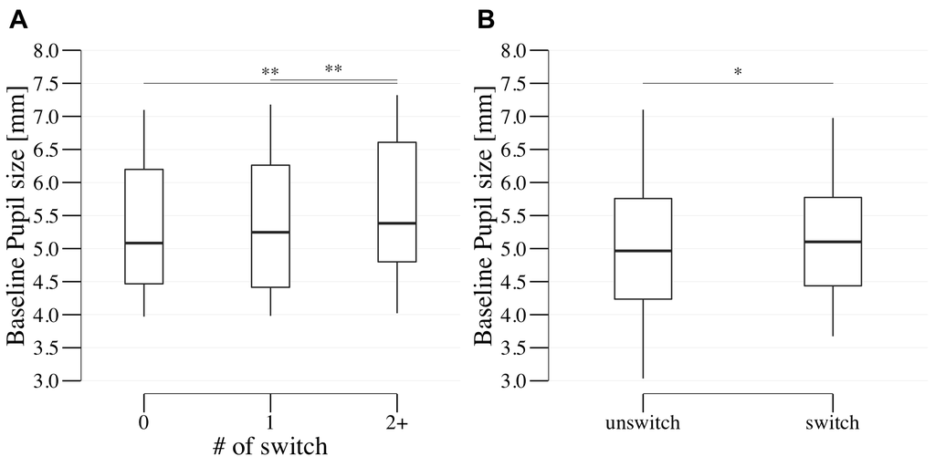

# Transient Pupil Dilation/Constriction (PD/PC)

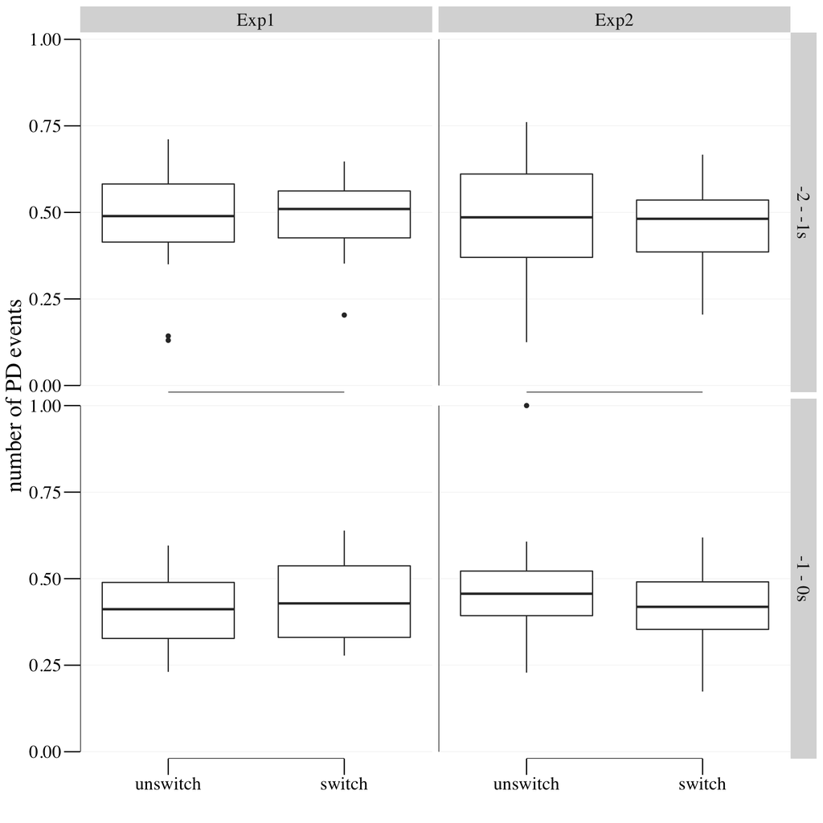

To address the concern the baseline pupil size might be affected by the PD events, we additionally analyzed the number of PD events in the baseline pupil size analysis window and 1s before the period (Supplemental Fig. 2A). The results showed that there were no significant main effect and interaction in both case ($F$(1,18) = 0.029, $p$ = 0.867, $\eta^2_p$ = 0.002, $BF_{10}$ = 0.243); $F$(1,18) = 0.112, $p$ = 0.742, $\eta^2_p$ = 0.006, $BF_{10}$ = 0.254; $F$(1,18) = 0.542, $p$ = 0.471, $\eta^2_p$ = 0.029, $BF_{10}$ = 0.361, respectively).